# Lab 5: Managing the recovery of predator-prey systems

Adelaide Dahl

# Announcements –

1. Paper selection for final project should be finalized by now.
2. **February 23, by 11:59pm** Mandatory code check-in: submit code for your model on Canvas. To get the most out of this, **show us an attempt at a timeseries (N vs. t)** and a written interpretation of the graph (~1 paragraph at most, please be concise!). This exercise functions to encourage you to start working on your code. For honors section and graduate students, proposals for model extensions are also due at this time.

This lab serves two purposes:  
(1) Provide a demonstration of the expectations for your final project, and  
(2) Complement what we’re learning in lecture about predator-prey dynamics.

Before coming to lab, you should have carefully read “Rapid and direct recoveries of predators and prey through synchronized ecosystem management” by Samhouri et al. (2017). Dr. Moeller will start lecture by presenting a 15-minute “chalk talk” about the paper. We will then work with code to recreate the paper’s predictions and test the effects of some of the authors’ core assumptions.

# 1. Studying the unharvested system

The equations for the model are given in Box 1, but the parameter values used for the simulations are hidden away in the tiny font Methods section that appears at the end of papers in the Nature family of journals.

The model has two species whose populations change in time: X, a prey species, and P, a predator. Although there is a second prey species “Y,” this species’s abundance is held constant over time, so for the purposes of the paper, Y is a parameter, not a state variable.

The biological dynamics (ignoring harvest for now) of each species are given by:

### Think, Pair, Share 1

1. Make a list of all the **variables** in the model and their meanings

X = number of prey K = carrying capacity P = number of predators

2. Make a list of all the **parameters** in the model and their meanings.

r = rate of change in prey population a = predation rare on prey population

3. What type of growth do the prey and predator exhibit?

logistic growth

## a. Set up

### Setting values for parameters

```r
r_x <- 1        # prey X's growth rate
K_x <- 100      # prey X's carrying capacity
a_x <- 0.03     # attack rate of predator on prey X
c <- 0.05       # predator's conversion efficiency
a_y <- 0.03     # attack rate of predator on prey Y
d_p <- 0.25     # mortality rate of predator
K_p <- 25       # predator's carrying capacity
Y <- 500        # abundance of other prey type
```

### Setting initial conditions

```r
X0 <- 1 # prey X initial population size
P0 <- 1 # predator initial population size
```

## b. Simulation

```r
# creating holding vectors and filling initial conditions
tset <- seq(from = 0, to = 100, length.out = 20000)
X.simu1 <- NaN*tset
X.simu1[1] <- X0
P.simu1 <- NaN*tset
P.simu1[1] <- P0

for(i in 2:length(tset)){
  # calculating change in time
    dt <- tset[i]-tset[i-1]

    # storing temporary variables
    X <- X.simu1[i-1]
    P <- P.simu1[i-1]

    # calculating change in population size of predator and prey
    dX <- ( r_x*X*(1-X/K_x) - a_x*P*X ) * dt
    dP <- ( P*(c*(a_x*X+a_y*Y)-d_p)*(1-P/K_p) ) * dt

    # calculating total population size of predator and prey
    # storing in holding vector
    X.simu1[i] <- X.simu1[i-1] + dX
    P.simu1[i] <- P.simu1[i-1] + dP
}
```

## c. Plotting

We’ll store colors for our predator and prey to keep our plots consistent through lab.

```r
# storing colors for predator and prey
Xcol <- 'deepskyblue'
Pcol <- 'firebrick'
```

Then, we can create our timeseries plot.

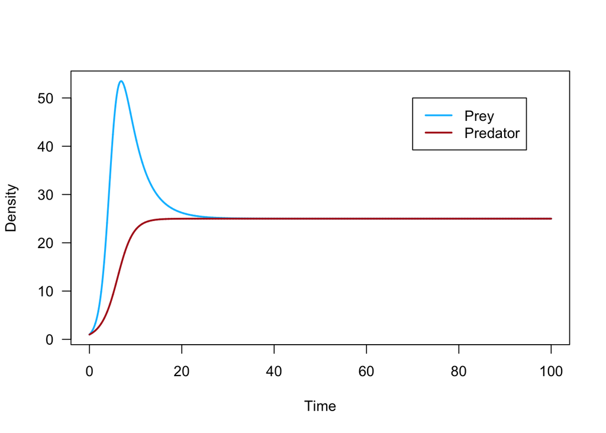

```r
# plot prey (X.simu1) against time (tset)
plot(x = tset, y = X.simu1,
     type = 'l', las = 1, lwd = 2, col = Xcol,
     xlab = 'Time', ylab = 'Density')

# plot predator (P.simu1) against time (tset)
lines(x = tset, y = P.simu1,
      lwd = 2, col = Pcol)

# add a legend
legend(x = 70, y = 50,
       lwd = 2,
       legend = c('Prey', 'Predator'),
       col = c(Xcol, Pcol))
```

# 2. Exploiting the system

## a. Setting new initial conditions

Samhouri et al. consider the unexploited system (i.e., with no hunting) to be the ‘baseline’ case. They then allow for exploitation by altering the equations to add a harvest term to each:

$$\begin{align}
\frac{d X}{dt} &= r_x X (1-\frac{ X}{K_x}) - a_x P X - h_x X\\
\newline
\frac{d P}{dt} &= P [c(a_x X + a_y Y) - d_p] (1-\frac{P}{K_p}) - h_p
P\\
\newline
\end{align}$$

So, let’s set our initial conditions to be the equilibrium state of the system without hunting:

```r
#
X0 <- X.simu1[length(tset)]
P0 <- P.simu1[length(tset)]
```

## b. Hunting rates

We will also need to set two new parameters for the hunting rates.

```r
h_x <- 0.65         # hunting rate of species X
h_p <- 0.325        # hunting rate of species P
```

If we look at Samhouri et al. Figure 2, panel a, we can see that during the “disassembly” of the system, predator hunting is initiated first (around t = 30), and prey hunting is started later (around t = 60). We can save these timepoints by assigning them to variables.

```r
#
t_Pstart <- 30

#
t_Xstart <- 60
```

## c. Simulating hunting with a for loop

In order to recreate Figure 2a, we are going to have to complicate our for loop a bit. In particular, we need to be able to turn hunting “on” at the timepoints chosen above. In order to do this, we’ll insert “if” statements into our for loop that allow for hunting only when the time is later than the startpoints chosen in the section above.

First, we’ll create our holding vectors and fill initial conditions, as usual.

```r
# creating holding vectors and filling initial conditions
tset <- seq(from = 0, to = 100, length.out = 20000)
X.simu2 <- NaN*tset
X.simu2[1] <- X0
P.simu2 <- NaN*tset
P.simu2[1] <- P0
```

Then, we’ll write our `for()` loop. This loop includes an `if` statement, which tells R: “If something is true, then do this - else, do something else.”

In the loop, we’re saying, “If this time is before the start time of hunting, then hunting = 0. Otherwise, hunting = the fixed hunting rate for that species.”

We’re also creating dummy variables called `h_p_now` and `h_x_now` to represent the hunting at *this timestep*. If the time is **before** the start time of hunting (for either species), `h_p_now` and `h_x_now` will equal 0. If the time is **after** the start time of hunting, then `h_p_now` and `h_x_now` will equal `h_p` and `h_x` respectively.

```r
for(i in 2:length(tset)){

  # ifelse statements for hunting
    if(tset[i] < t_Pstart){ h_p_now <- 0 } ##setting the if statement for when h_p_now is 0
  else { h_p_now <- h_p } ##and if its not, then set h_p_now to be h_p

    if(tset[i] < t_Xstart){ h_x_now <- 0 } ##doing the same as above for h_x_now
  else { h_x_now <- h_x } ## ##doing the same as above for h_x_now and h_x

  # calculating change in time
    dt <- tset[i]-tset[i-1]

    #
    X <- X.simu2[i-1]
    P <- P.simu2[i-1]

    # calculating change in population size for predator and prey
    dX <- ( r_x*X*(1-X/K_x) - a_x*P*X - h_x_now*X ) * dt #equation for prey with hunting
    dP <- ( P*(c*(a_x*X+a_y*Y)-d_p)*(1-P/K_p) - h_p_now*P ) * dt #equation for predators with hunting

    # calculating total population size for predator and prey
    X.simu2[i] <- X.simu2[i-1] + dX
    P.simu2[i] <- P.simu2[i-1] + dP
}
```

Don’t forget to check the output of your loop!

```r
head(X.simu2)
```

[output not shown]

## d. Plotting results

Cross your fingers that it looks like Fig. 2a!

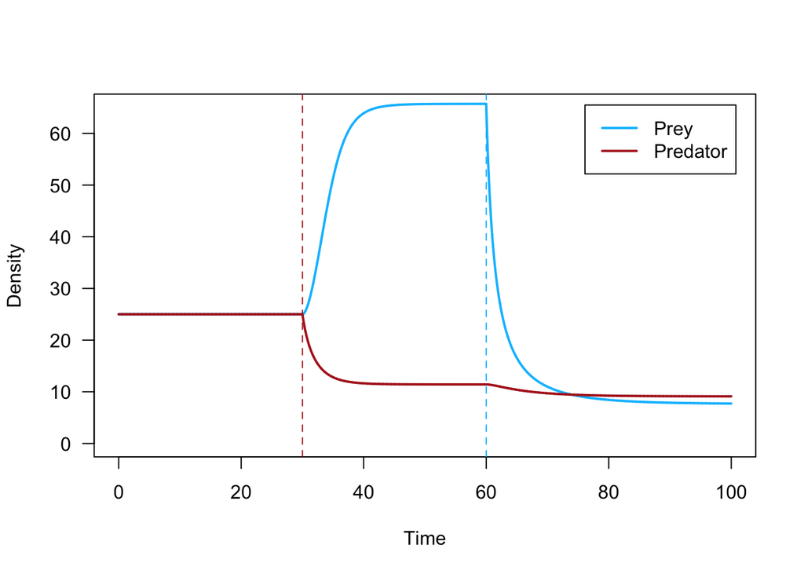

```r
# Scenario 2:
#

# plot prey (X.simu2) against time (tset)
plot(x = tset, y = X.simu2,
     type = 'l', las = 1, lwd = 2, col = Xcol,
     xlab = 'Time', ylab = 'Density',
     ylim = c(0, 65))

# plot predator (P.simu2) against time (tset)
lines(x = tset, y = P.simu2,
      lwd = 2, col = Pcol)

# add a legend
## New legend arguments!! What do they do? ##
legend(x = 'topright',  # turns out we can tell R to put the legend in a physical place on the plot
       inset = 0.03,   # the inset argument tells R how far inside the axes to place the legend
       lwd = 2,
       legend = c('Prey','Predator'),
       col = c(Xcol, Pcol))

# add vertical lines to indicate where hunting was turned on for each species
abline(v = t_Pstart, lty = 2, col = Pcol)
abline(v = t_Xstart, lty = 2, col = Xcol)
```

It worked!

# 3. Recovering the system

## a. Setting new initial conditions and time windows

Samhouri et al. consider three ‘recovery’ scenarios: One in which hunting of prey and predator is stopped simultaneously, one in which hunting of the predator is stopped first, and one in which hunting of the prey is stopped first.

Because the system is going to be recovering, our initial conditions need to be those of the “disassembled” state (which we just plotted).

```r
#
X0_dis <- X.simu2[length(tset)]
P0_dis <- P.simu2[length(tset)]
```

We’re also going to be running our simulation over a different range of time, picking up where we left off above at t = 100, and running the model for a further 110 years.

**Note:** the length of the tset2 vector is 21,000 (compared to 20,000 for tset). This is a coding ‘trick’ to help catch errors when we make plots later. If we try to plot the model results (a .simu vector) with the wrong timeset, we’ll get an error message saying that the dimensions of the vectors don’t agree. This is an indication that we have put in the wrong timeset!

```r
tset2 <- seq(from = 100, to = 210,length.out = 21000)
```

### Think, Pair, Share 2

1. Study Samhouri et al. Figure 2, panel b. At what time are prey and predator hunting stopped? Assign this time to a parameter called `t_stophunt`.

```r
t_stophunt <- 110
```

2. From Figure 2, panel c, at what time is the prey hunting stopped? Assign this time to a parameter called `t_stopX`.

```r
t_stopX <- 140
```

3. From Figure 2, panel d, at what time is the predator hunting stopped? Assign this time to a parameter called `t_stopP`.

```r
t_stopP <- 149
```

## b. Scenario 1: Synchronous recovery

Now, we’re ready to run our first simulation! Pay close attention to how the `if` statements in the for loop have been modified. This should recreate Fig 2b.

```r
# creating holding vectors and storing initial conditions
X.simu3 <- NaN*tset2
X.simu3[1] <- X0_dis
P.simu3 <- NaN*tset2
P.simu3[1] <- P0_dis

# using tset2: time from 100 to 210
for(i in 2:length(tset2)){ #start at time step 2 from the second time step we set

  # if else statements
  ## if current time step is before (less than) t_stophunt hunting pressure stays as h_p
  ## else hunting pressure is set to 0 (no hunting after t_stophunt)
    if(tset2[i] < t_stophunt){ h_p_now <- h_p } else { h_p_now <- 0 }

  ## if current time step is before (less than) t_stophunt hunting pressure stays as h_x
  ## else hunting pressure is set to 0 (no hunting after t_stophunt)
    if(tset2[i] < t_stophunt){ h_x_now <- h_x } else { h_x_now <- 0 }

  # calculating change in time
    dt <- tset2[i]-tset2[i-1]

    # storing temporary variables
    X <- X.simu3[i-1] #prey at previous step
    P <- P.simu3[i-1] #preds at previous step

    # calculating change in population size
    dX <- (r_x*X*(1-X/K_x) - a_x*P*X - h_x_now*X ) * dt #hunting equation for prey
    dP <- (P*(c*(a_x*X+a_y*Y)-d_p)*(1-P/K_p) - h_p_now*P ) * dt #hunting equation for preds

    # calculating total population size and storing in holding vector
    X.simu3[i] <- X.simu3[i-1] + dX
    P.simu3[i] <- P.simu3[i-1] + dP
}
```

Don’t forget to check the output of your loop!

```r
head(P.simu3)
```

[output not shown]

After checking our results, we can plot our timeseries.

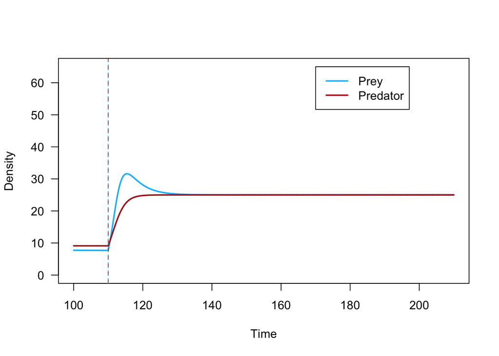

```r
# Scenario 3:
#

# plot prey (X.simu3) against time (tset2)
plot(x = tset2, y = X.simu3,
     type = 'l', las = 1, lwd = 2, col = Xcol,
     xlab = 'Time', ylab = 'Density',
     ylim = c(0, 65))

# plot predator (P.simu3) against time (tset2)
lines(x = tset2, y = P.simu3,
      lwd = 2, col = Pcol)

# add a legend
legend(x = 170, y = 65,
       lwd = 2,
       legend = c('Prey', 'Predator'),
       col = c(Xcol, Pcol))

# add vertical lines to indicate where hunting stopped
abline(v = t_stophunt, lty = 2, col = Pcol)
abline(v = t_stophunt, lty = 3, col = Xcol)
```

Looks liek fig 2b!

## c. Predator-first recovery

Now we’ll run the second possibility and try to re-create the graph in Figure 2c. Note that we’re saving this as our fourth simulation (`X.simu4` and `P.simu4`)!

Notice what’s new about the `if` statements in the loop: instead of having hunting stop for predator and prey at the same time (i.e. having `t_stophunt` in both statements), we’re using `t_stophunt` for the predator and `t_stopX` for the prey.

```r
# creating holding vectors and storing initial conditions
X.simu4 <- NaN*tset2
X.simu4[1] <- X0_dis
P.simu4 <- NaN*tset2
P.simu4[1] <- P0_dis

for(i in 2:length(tset2)){

  # if time is before t_stophunt, h_p_now = h_p
  # else, h_p_now = 0
    if(tset2[i] < t_stophunt){ h_p_now <- h_p } else { h_p_now <- 0 }

  # if time is before t_stopX, h_x_now = h_x
  # else, h_x_now = 0
    if(tset2[i] < t_stopX){ h_x_now <- h_x } else { h_x_now <- 0 }

  # calculating change in time
    dt <- tset2[i]-tset2[i-1]

    # storing temporary variables
    X <- X.simu4[i-1]
    P <- P.simu4[i-1]

    # calculating change in population size
    dX <- ( r_x*X*(1-X/K_x) - a_x*P*X - h_x_now*X ) * dt #prey
    dP <- ( P*(c*(a_x*X+a_y*Y)-d_p)*(1-P/K_p) - h_p_now*P ) * dt #pred

    # calculating total population size and storing in holding vector
    X.simu4[i] <- X.simu4[i-1] + dX
    P.simu4[i] <- P.simu4[i-1] + dP
}
```

Check the output of your loop!

```r
head(X.simu4)
```

[output not shown]

### Think, Pair, Share 3

1. Using the plotting code from part 3 above, make a plot of these results.

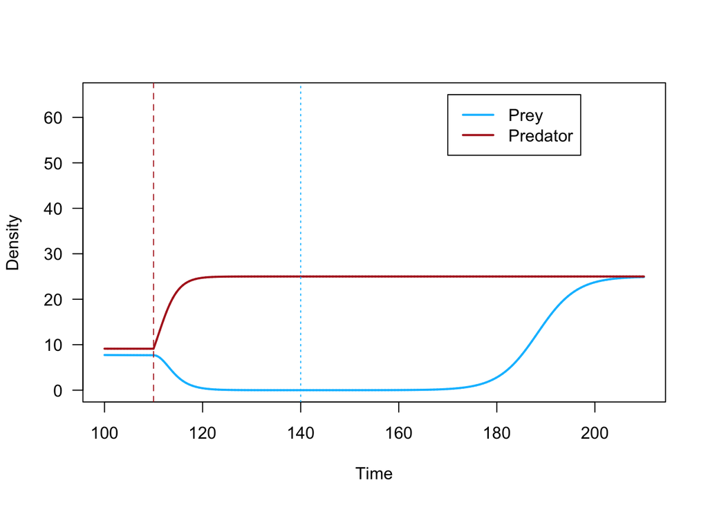

```r
# Scenario 4:
#

# plot prey (X.simu4) against time (tset2)
plot(x = tset2, y = X.simu4,
     type = 'l', las = 1, lwd = 2, col = Xcol,
     xlab = 'Time', ylab = 'Density',
     ylim = c(0, 65))

# plot predator (P.simu4) against time (tset2)
lines(x = tset2, y = P.simu4,
      lwd = 2, col = Pcol)

# add a legend
legend(x = 170, y = 65,
       lwd = 2,
       legend = c('Prey', 'Predator'),
       col = c(Xcol, Pcol))

# add vertical lines to indicate where hunting stopped
abline(v = t_stophunt, lty = 2, col = Pcol)
abline(v = t_stopX, lty = 3, col = Xcol)
```

```r
#the population recovered but a while after hunting pressure stopped (redrew line as well)
```

##?should this be moved??

## d. Prey-first recovery

#### Think, Pair, Share 4

As you have for Scenarios 1 and 2, simulate recovery, but, in this case, consider the prey-first recovery. Hint: Copy/paste code from above, but don’t forget to create new storage vectors (e.g., `X.simu5` and `P.simu5`) to hold your results!

## Do i need to change t_stop_X to be before the t_stophunt?

Put your code for the `for()` loop here:

```r
# creating holding vectors and storing initial conditions
X.simu5 <- NaN*tset2
X.simu5[1] <- X0_dis
P.simu5 <- NaN*tset2
P.simu5[1] <- P0_dis

for(i in 2:length(tset2)){

  # if time is before t_stophunt, h_x_now = h_x --> switched hunting stop with time above
  # else, h_x_now = 0
    if(tset2[i] < t_stophunt){ h_x_now <- h_x } else { h_x_now <- 0 }

  # if time is before t_stopX, h_p_now = h_p --> switched with above
  # else, h_p_now = 0
    if(tset2[i] < t_stopX){ h_p_now <- h_p } else { h_p_now <- 0 }

  # calculating change in time
    dt <- tset2[i]-tset2[i-1]

    # storing temporary variables
    X <- X.simu5[i-1]
    P <- P.simu5[i-1]

    # calculating change in population size
    dX <- ( r_x*X*(1-X/K_x) - a_x*P*X - h_x_now*X ) * dt #prey
    dP <- ( P*(c*(a_x*X+a_y*Y)-d_p)*(1-P/K_p) - h_p_now*P ) * dt #pred

    # calculating total population size and storing in holding vector
    X.simu5[i] <- X.simu5[i-1] + dX
    P.simu5[i] <- P.simu5[i-1] + dP
}
```

And your code for your plot here:

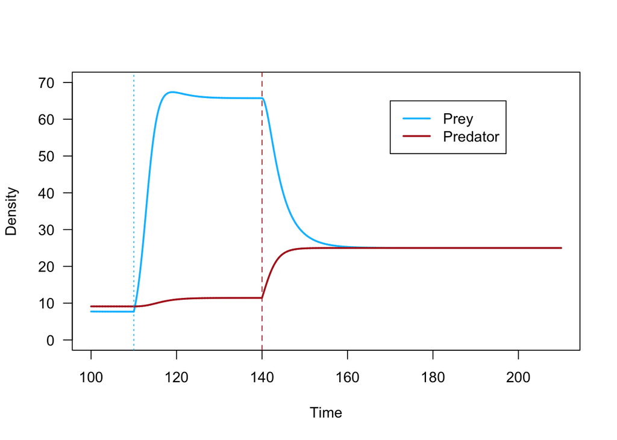

```r
# Scenario 5:
#

# plot prey (X.simu4) against time (tset2)
plot(x = tset2, y = X.simu5,
     type = 'l', las = 1, lwd = 2, col = Xcol,
     xlab = 'Time', ylab = 'Density',
     ylim = c(0, 70)) #needed more space here

# plot predator (P.simu4) against time (tset2)
lines(x = tset2, y = P.simu5,
      lwd = 2, col = Pcol)

# add a legend
legend(x = 170, y = 65,
       lwd = 2,
       legend = c('Prey', 'Predator'),
       col = c(Xcol, Pcol))

# add vertical lines to indicate where hunting stopped
abline(v = t_stopX, lty = 2, col = Pcol)
abline(v = t_stophunt, lty = 3, col = Xcol)
```

# 4. Lining up the scenarios in time

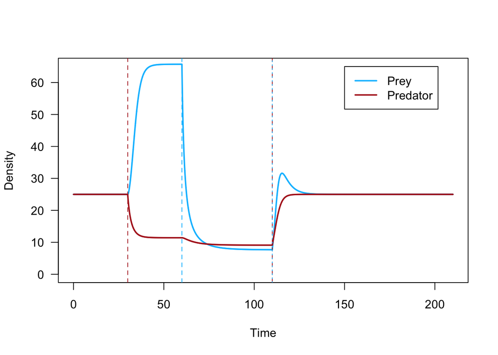

```r
#
## plot prey
plot(x = tset, y = X.simu2,
     type = 'l', las = 1, lwd = 2, col = Xcol,
     xlab = 'Time', ylab = 'Density',
     xlim = c(0, 210), ylim = c(0, 65))
## plot predator
lines(x = tset, y = P.simu2,
      lwd = 2, col = Pcol)

#
## plot prey
lines(x = tset2, y = X.simu3,
      lwd = 2, col = Xcol)
## plot predator
lines(x = tset2, y = P.simu3,
      lwd = 2, col = Pcol)

# add a legend
legend(x = 150, y = 65,
       legend = c('Prey','Predator'),
       lwd = 2,
       col = c(Xcol, Pcol))

# add vertical lines to indicate where hunting started
abline(v = t_Xstart, lty = 2, col = Xcol)
abline(v = t_Pstart, lty = 2, col = Pcol)

# ad vertical lines to indicate where hunting ended
abline(v = t_stophunt, lty = 2, col = Pcol)
abline(v = t_stophunt, lty = 3, col = Xcol)
```

Those vertical lines are a little cumbersome. Let’s borrow a page from the paper and use coloured bars to indicate when each species is being harvested instead.

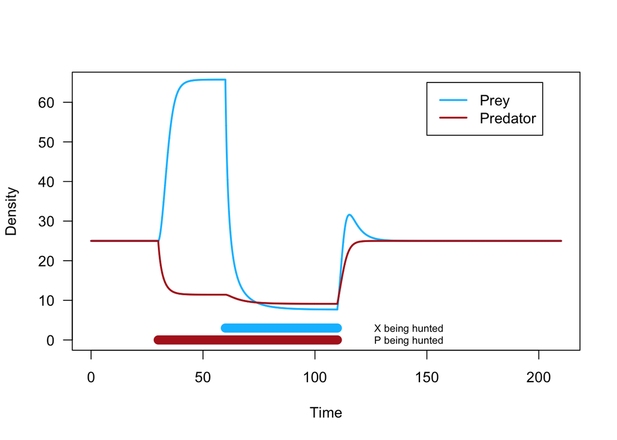

```r
#
## plot prey
plot(x = tset, y = X.simu2,
     type = 'l', las = 1, lwd = 2, col = Xcol,
     xlab = 'Time', ylab = 'Density',
     xlim = c(0, 210), ylim = c(0, 65))
## plot predator
lines(x = tset, y = P.simu2,
      lwd = 2, col = Pcol)

#
## plot prey
lines(x = tset2, y = X.simu3,
      lwd = 2, col = Xcol)
## plot predator
lines(x = tset2, y = P.simu3,
      lwd = 2, col = Pcol)

# add a legend
legend(x = 150, y = 65,
       legend = c('Prey','Predator'),
       lwd = 2,
       col = c(Xcol, Pcol))

# add horizontal line to indicate when prey hunting occurred
lines(x = c(t_Xstart, t_stophunt), y = c(3, 3),
      lwd = 10, col = Xcol)
text(x = 142, y = 2.8, 'X being hunted', cex = .7)

# add horizontal line to indicate where predator hunting occurred
lines(x = c(t_Pstart, t_stophunt), y = c(0, 0),
      lwd = 10, col = Pcol)
text(x = 142, y = -.2, 'P being hunted', cex = .7)
```

# 5. Using bifurcation diagrams to evaluate model assumptions

One of the major assumptions that has always bothered me (Dr. Moeller) about this paper is that there is a second prey species, Y, which is not dynamic. In other words, it’s not being affected by hunting, nor is it being affected by the predator population.

Because Y is not dynamic, it’s a parameter in this system. So we can make a bifurcation diagram studying the equilibria of the model with respect to Y.

There are two ways we can do this: Analytically (on pen and paper, using algebra to solve $\frac{dP}{dt} = \frac{dX}{dt} = 0$), or numerically. Mathematical ecologists will usually take an analytical approach whenever possible because (1) it’s more accurate because you also find the unstable equilibria that your simulations will not reveal, (2) it’s less computationally intensive, and (3) it’s more fun! But for some of your projects, you’ll need to generate bifurcation diagrams numerically, so that’s what we’ll do here.

Because numerical approaches are bad at finding unstable equilibria (because there’s almost no chance you’ll land, unperturbed, on that equilibrium and stay there over simulation time), we’ll ignore the unstable equilibrium at X = 0, P = 0, though this equilibrium is readily apparently from the equations. (Think about how you could factor out an X from dX/dt and a P from dP/dt, and what that means when you set those equations equal to zero to find equilibria.)

## a. Selecting the x-axis for our bifurcation diagram

We’ll use `seq` to create a sequence of values of Y for which we’ll look at the model’s equilibria.

```r
Yset <- seq(from = 0, to = 1000,length.out = 50)
```

## b. Calculating the equilibrium points for each value of Y

We need to do a loop of loops: for each value of Y within `Yset`, we’ll run the numerical simulation (looping over all values of t in `tset`), and save the output as the equilibrium.

NOTE: For this to work, you have to be confident that your timeset is long enough for the model to reach equilibrium! Based on our simulations in Part One, we can feel pretty good about having time run to 100:

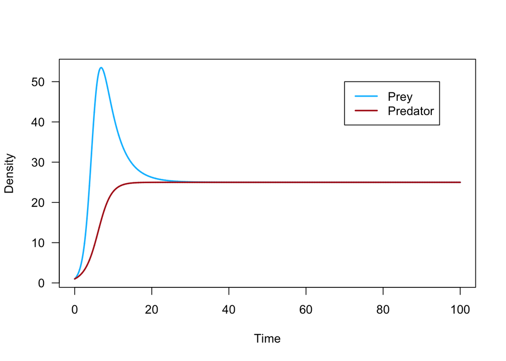

```r
# checking to make sure that simulation has reached equilibrium

# plot prey (X.simu1) against time
plot(x = tset, y = X.simu1,
     type = 'l', las = 1, lwd = 2, col = Xcol,
     xlab = 'Time', ylab = 'Density')

# plot predator a(P.simu1) against time
lines(x = tset, y = P.simu1,
      lwd = 2, col = Pcol)

# add a legend
legend(x = 70, y = 50,
       legend = c('Prey','Predator'),
       col = c(Xcol, Pcol),
       lwd = 2)
```

First, we create storage variables for our two state variables of interest.

```r
Xstarset <- NaN*Yset
Pstarset <- NaN*Yset
```

Second, we run our for loop. Note that we’re using `j` as our index of Y values. It’s important that each nested for loop using a different index variable. Otherwise, indices are getting reset within loops and you could get stuck in a loop of loops of loops of….

```r
for(j in 1:length(Yset)){
  # assign the value of Y
    Y <- Yset[j]

    # create a holding vector for predator and prey populations
    # and fill with initial conditions
    X.simu <- NaN*tset
    X.simu[1] <- 1
    P.simu <- NaN*tset
    P.simu[1] <- 1

    for(i in 2:length(tset)){
      # calculating change in time
        dt <- tset[i]-tset[i-1]

        # storing temporary variables
        X <- X.simu[i-1]
        P <- P.simu[i-1]

        # calculating change in population size
        dX <- ( r_x*X*(1-X/K_x) - a_x*P*X - h_x*X ) * dt
        dP <- ( P*(c*(a_x*X+a_y*Y)-d_p)*(1-P/K_p) - h_p*P ) * dt

        # calculating total population size
        X.simu[i] <- X.simu[i-1] + dX
        P.simu[i] <- P.simu[i-1] + dP
    }

    # storing last population size (equilibrium population size) in holding vector
    Xstarset[j] <- X.simu[length(tset)]
    Pstarset[j] <- P.simu[length(tset)]

}
```

## c. Examining the results

We can now make bifurcation diagrams for both X and P.

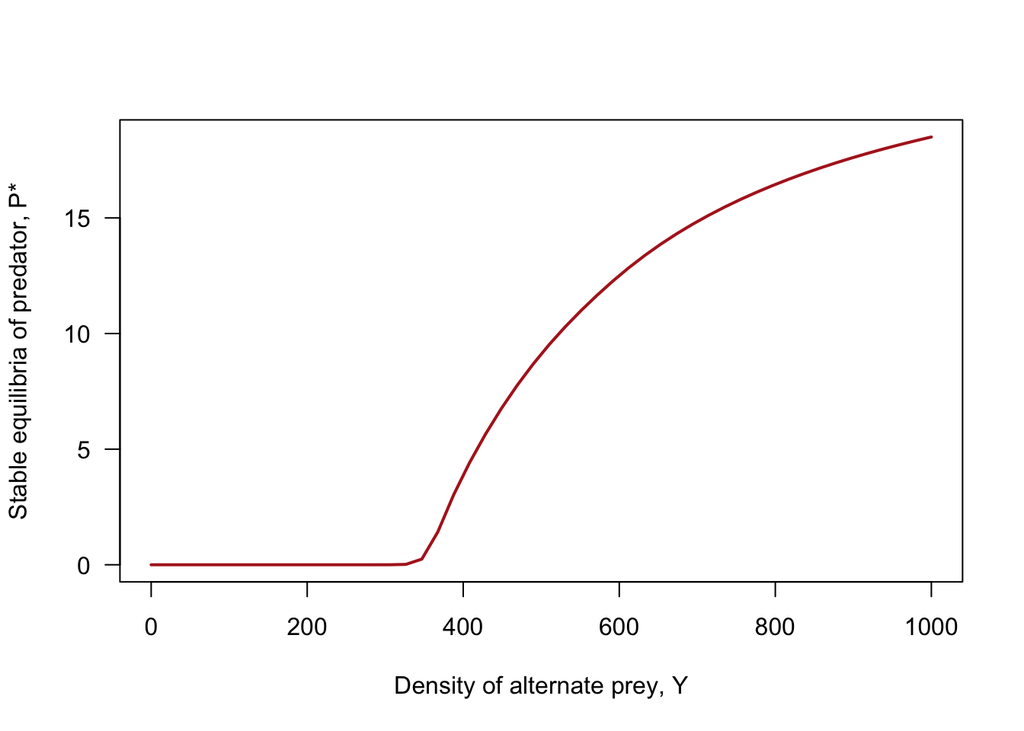

```r
# plot stable equilibria of predator (Pstarset) against density of alternate prey (Yset)
plot(x = Yset, y = Pstarset,
     type = 'l', lwd = 2, col = Pcol, las = 1,
     xlab = 'Density of alternate prey, Y', ylab = 'Stable equilibria of predator, P*')
```

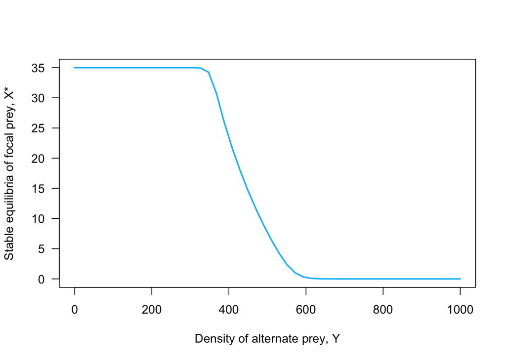

```r
# plot stable equilibria of prey (Xstarset) against density of alternate prey (Yset)
plot(x = Yset, y = Xstarset,
     type = 'l', lwd = 2, col = Xcol, las = 1,
     xlab = 'Density of alternate prey, Y', ylab = 'Stable equilibria of focal prey, X*')
```

# 6. Homework

## Set up

Set up any variables you need in this code chunk.

```r
r_x <- 1        # prey X's growth rate
K_x <- 100      # prey X's carrying capacity
a_x <- 0.03     # attack rate of predator on prey X
c <- 0.05       # predator's conversion efficiency
a_y <- 0.03     # attack rate of predator on prey Y
d_p <- 0.25     # mortality rate of predator
K_p <- 25       # predator's carrying capacity
Y <- 500        # abundance of other prey type

# storing colors for predator and prey
Xcol <- 'deepskyblue' #preds
Pcol <- 'firebrick' #prey

#set our initial conditions to be the equilibrium state of the system without hunting:
X0 <- X.simu1[length(tset)] #intial for prey
P0 <- P.simu1[length(tset)] #initial for preds
```

###Hunting rates We will also need to set two new parameters for the hunting rates.

```r
h_x <- 0.65         # hunting rate of species X
h_p <- 0.325        # hunting rate of species P
```

If we look at Samhouri et al. Figure 2, panel a, we can see that during the “disassembly” of the system, predator hunting is initiated first (around t = 30), and prey hunting is started later (around t = 60). We can save these timepoints by assigning them to variables.

```r
# time start for preds
t_Pstart <- 30
# time start for prey
t_Xstart <- 60
```

### Simulating hunting with a for loop

In order to recreate Figure 2a, we are going to have to complicate our for loop a bit. In particular, we need to be able to turn hunting “on” at the timepoints chosen above. In order to do this, we’ll insert “if” statements into our for loop that allow for hunting only when the time is later than the startpoints chosen in the section above.

First, we’ll create our holding vectors and fill initial conditions, as usual - for both time steps

```r
# creating holding vectors and filling initial conditions
tset <- seq(from = 0, to = 100, length.out = 20000)
X.simu2 <- NaN*tset
X.simu2[1] <- X0
P.simu2 <- NaN*tset
P.simu2[1] <- P0
```

Then, we’ll write our `for()` loop. This loop includes an `if` statement, which tells R: “If something is true, then do this - else, do something else.”

In the loop, we’re saying, “If this time is before the start time of hunting, then hunting = 0. Otherwise, hunting = the fixed hunting rate for that species.”

We’re also creating dummy variables called `h_p_now` and `h_x_now` to represent the hunting at *this timestep*. If the time is **before** the start time of hunting (for either species), `h_p_now` and `h_x_now` will equal 0. If the time is **after** the start time of hunting, then `h_p_now` and `h_x_now` will equal `h_p` and `h_x` respectively.

```r
for(i in 2:length(tset)){ #start indexing at time step 2

  # ifelse statements for hunting
    if(tset[i] < t_Pstart){ h_p_now <- 0 } ##setting the if statement for when h_p_now is 0
  else { h_p_now <- h_p } ##and if its not, then set h_p_now to be h_p

    if(tset[i] < t_Xstart){ h_x_now <- 0 } ##doing the same as above for h_x_now
  else { h_x_now <- h_x } ## ##doing the same as above for h_x_now and h_x

  # calculating change in time
    dt <- tset[i]-tset[i-1]

    # storing temporary variables
    X <- X.simu2[i-1]
    P <- P.simu2[i-1]

    # calculating change in population size for predator and prey
    dX <- ( r_x*X*(1-X/K_x) - a_x*P*X - h_x_now*X ) * dt #equation for prey with hunting
    dP <- ( P*(c*(a_x*X+a_y*Y)-d_p)*(1-P/K_p) - h_p_now*P ) * dt #equation for predators with hunting

    # calculating total population size for predator and prey
    X.simu2[i] <- X.simu2[i-1] + dX
    P.simu2[i] <- P.simu2[i-1] + dP
}
```

### stop hunting estimates

1. Study Samhouri et al. Figure 2, panel b. At what time are prey and predator hunting stopped? Assign this time to a parameter called `t_stophunt`.
2. From Figure 2, panel c, at what time is the prey hunting stopped? Assign this time to a parameter called `t_stopX`.
3. From Figure 2, panel d, at what time is the predator hunting stopped? Assign this time to a parameter called `t_stopP`.

```r
t_stophunt <- 110 #1
t_stopX <- 140 #2
t_stopP <- 149 #3
```

## Prey first recovery 100 to 210

```r
# creating holding vectors and storing initial conditions
# creating holding vectors and storing initial conditions
X.simu5 <- NaN*tset2
X.simu5[1] <- X0_dis
P.simu5 <- NaN*tset2
P.simu5[1] <- P0_dis

for(i in 2:length(tset2)){

  # if time is before t_stophunt, h_x_now = h_x --> switched hunting stop with time above
  # else, h_x_now = 0
    if(tset2[i] < t_stophunt){ h_x_now <- h_x } else { h_x_now <- 0 }

  # if time is before t_stopX, h_p_now = h_p --> switched with above
  # else, h_p_now = 0
    if(tset2[i] < t_stopX){ h_p_now <- h_p } else { h_p_now <- 0 }

  # calculating change in time
    dt <- tset2[i]-tset2[i-1]

    # storing temporary variables
    X <- X.simu5[i-1]
    P <- P.simu5[i-1]

    # calculating change in population size
    dX <- ( r_x*X*(1-X/K_x) - a_x*P*X - h_x_now*X ) * dt #prey
    dP <- ( P*(c*(a_x*X+a_y*Y)-d_p)*(1-P/K_p) - h_p_now*P ) * dt #pred

    # calculating total population size and storing in holding vector
    X.simu5[i] <- X.simu5[i-1] + dX
    P.simu5[i] <- P.simu5[i-1] + dP
}
```

# HW 1

Question 1: Timeseries plot

Make a timeseries plot like that in Part 4 (i.e., showing a timeseries from year 0 to year 210) for the scenario in which prey are allowed to recover before predators (i.e., combining figures 2a and 2d from Samhouri et al.).

Be sure to (1) label your axes, (2) include a legend, and (3) indicate when harvest of predators and prey is occurring.

[figure not shown]

```r
## plot prey from simulation 2 where
plot(x = tset, y = X.simu2, #putting prey into y axis, timeseries along x
     type = 'l', las = 1, lwd = 2, col = Xcol, #visuals
     xlab = 'Time', ylab = 'Density', #labels
     xlim = c(0, 210), ylim = c(0, 70)) #bounds of axes
## plot predator
lines(x = tset, y = P.simu2, #adding pred line
      lwd = 2, col = Pcol) #visuals

#this part is for the second half of the graph - later chunk of time steps
## plot prey
lines(x = tset2, y = X.simu5, #prey from this for() loop
      lwd = 2, col = Xcol) #visuals
## plot predator
lines(x = tset2, y = P.simu5, #predator for this for() loop in y axis
      lwd = 2, col = Pcol) #visuals

# add a legend
legend(x = 150, y = 65, #position of legend
       legend = c('Prey','Predator'), #labels
       lwd = 2, #line type
       col = c(Xcol, Pcol)) #arrangement

# add horizontal line to indicate when prey hunting occurred
lines(x = c(t_Xstart, t_stophunt), y = c(3, 3),
      lwd = 10, col = Xcol)
text(x = 142, y = 2.8, 'Prey being hunted', cex = .7)

# add horizontal line to indicate where predator hunting occurred
lines(x = c(t_Pstart, t_stopP), y = c(0, 0),
      lwd = 10, col = Pcol)
text(x = 180, y = -.2, 'Predator being hunted', cex = .7)
```

/1 axes  
/1 legend  
/1 graphical indication of predator harvest  
/1 graphical indication of prey harvest  
/2 one point per simulation line (exploitation phase)  
/2 one point per simulation line (recovery phase)  
= /8 points total

# HW 2

Question 2: Effects of changing alternate prey availability

To interpret the effects of changing alternate prey availability –

## 2A

1. Paste your bifurcation diagrams (make sure the plots show up when you knit!) from part 5c here. (You should have two – one for $X^*$, and one for $P^*$, both with respect to Y.)

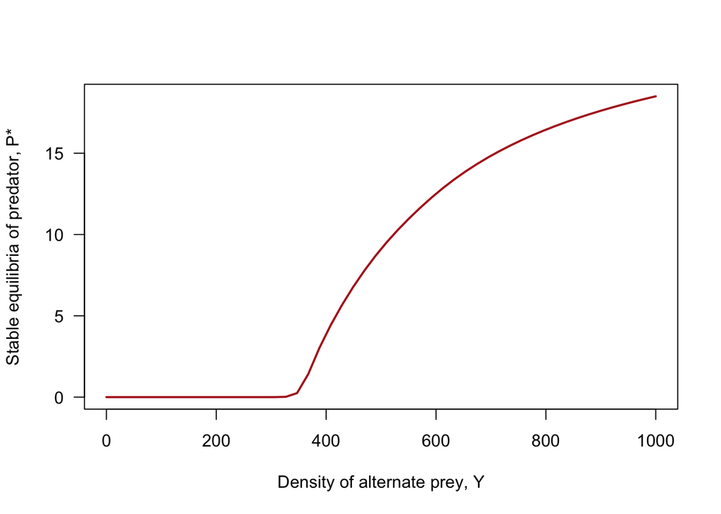

```r
# plot stable equilibria of predator (Pstarset) against density of alternate prey (Yset)
plot(x = Yset, y = Pstarset,
     type = 'l', lwd = 2, col = Pcol, las = 1,
     xlab = 'Density of alternate prey, Y', ylab = 'Stable equilibria of predator, P*')
```

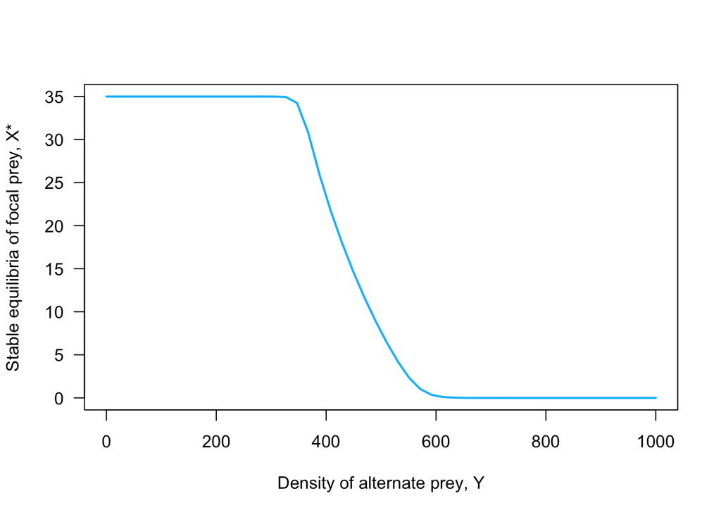

```r
# plot stable equilibria of prey (Xstarset) against density of alternate prey (Yset)
plot(x = Yset, y = Xstarset,
     type = 'l', lwd = 2, col = Xcol, las = 1,
     xlab = 'Density of alternate prey, Y', ylab = 'Stable equilibria of focal prey, X*')
```

/2 axes for two plots  
/2 X* or P* lines in two plots  
= /4 points total

## 2B

2. Describe in biological terms what is happening as the alternate prey increases in density.

**As the alternate prey increases in density, the stable equilibria value for the predator increases. In biological terms this means that there is a density dependent impact of prey Y on predators. The stable equilibria value being pushed higher suggests a positive interaction between prey Y and the predator population. This would make sense as we look at the interaction between the two prey species (the second figure). As the alternate prey (Y) increases, it also drives down the value of the stable equilibria of the focal prey, suggesting a negative interaction between the two, driven by density dependent effects.**

= /2 points total

## 2C

3. Look up the term “apparent competition.” How does your bifurcation diagram of $X^*$ with respect to Y show this phenomenon?

**According to the internet apparent competition is “when two species indirectly compete for survival through a shared predator or pathogen.” The bifurcation diagram shows that these prey are interacting. Prey Y density is related to an increase in predator stable equilibria and around the same point in prey Y density, prey X interacts with prey Y on the second figure, so it is reasonable to infer that these two organisms (prey Y and X) are interacting through their relationships to the predator population.**

= /2 points total

# HW 3

Question 3: Choose your own bifurcation adventure

## 3A

1. Choose a parameter other than Y, and make two bifurcation diagrams with this parameter on the x-axis. One bifurcation diagram should show the stable prey equilibrium ($X*$), and the other should show the stable predator equilibrium ($P*$).

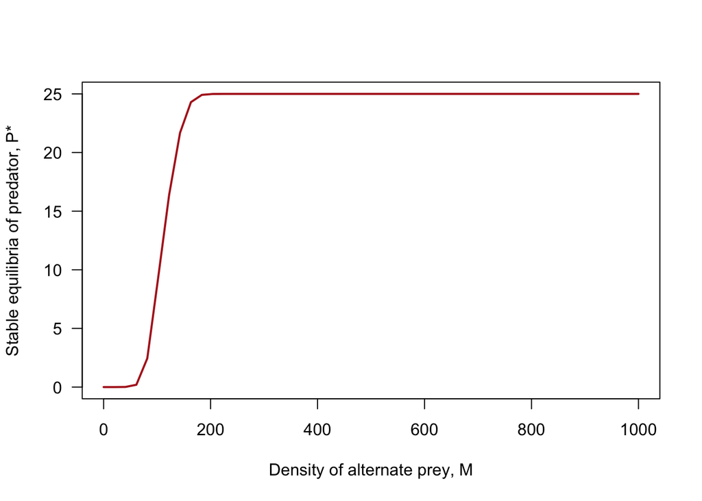

```r
#my parameter will be M
Mset <- seq(from = 0, to = 1000,length.out = 50)

for(j in 1:length(Mset)){
  # assign the value of Y
    Y <- Mset[j]

    # create a holding vector for predator and prey populations
    # and fill with initial conditions
    X.simu <- NaN*tset
    X.simu[1] <- 1
    P.simu <- NaN*tset
    P.simu[1] <- 1

    for(i in 2:length(tset)){
      # calculating change in time
        dt <- tset[i]-tset[i-1]

        # storing temporary variables
        X <- X.simu[i-1]
        P <- P.simu[i-1]

        # calculating change in population size
        dX <- ( r_x*X*(1-X/K_x) - a_x*P*X ) * dt #equation without hunting
        dP <- ( P*(c*(a_x*X+a_y*Y)-d_p)*(1-P/K_p)) * dt #equation without hunting

        # calculating total population size
        X.simu[i] <- X.simu[i-1] + dX
        P.simu[i] <- P.simu[i-1] + dP
    }

    # storing last population size (equilibrium population size) in holding vector
    Xstarset[j] <- X.simu[length(tset)]
    Pstarset[j] <- P.simu[length(tset)]

}

Xstarset2 <- NaN*Mset
Pstarset2 <- NaN*Mset

# plot stable equilibria of predator (Pstarset) against density of alternate prey (Mset)
plot(x = Mset, y = Pstarset,
     type = 'l', lwd = 2, col = Pcol, las = 1,
     xlab = 'Density of alternate prey, M', ylab = 'Stable equilibria of predator, P*')
```

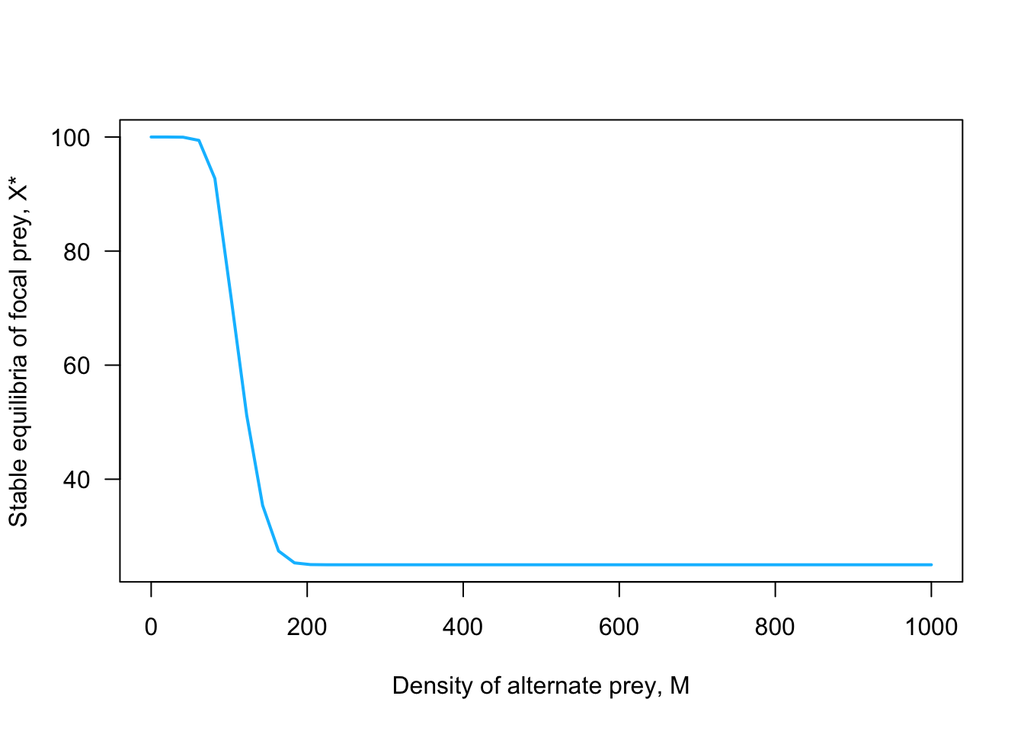

```r
# plot stable equilibria of prey (Xstarset) against density of alternate prey (Mset)
plot(x = Mset, y = Xstarset,
     type = 'l', lwd = 2, col = Xcol, las = 1,
     xlab = 'Density of alternate prey, M', ylab = 'Stable equilibria of focal prey, X*')
```

/2 axes for two plots  
/2 X* or P* lines in two plots  
= /4 points total

## 3B

2. Describe in biological terms what is happening. Do your results make intuitive sense?

= /2 points total

# HW 4

Question 4: Impacts of reduced alternate prey on recovery scenarios

## 4A

1. Set `Y` = 200. Using the same harvest rates we have chosen above (`h_x` = 0.65 and `h_p` = 0.325), find the equilibrium population sizes when harvest is occurring (i.e., in a “disassembled” or “exploited” system).

###using harvest model

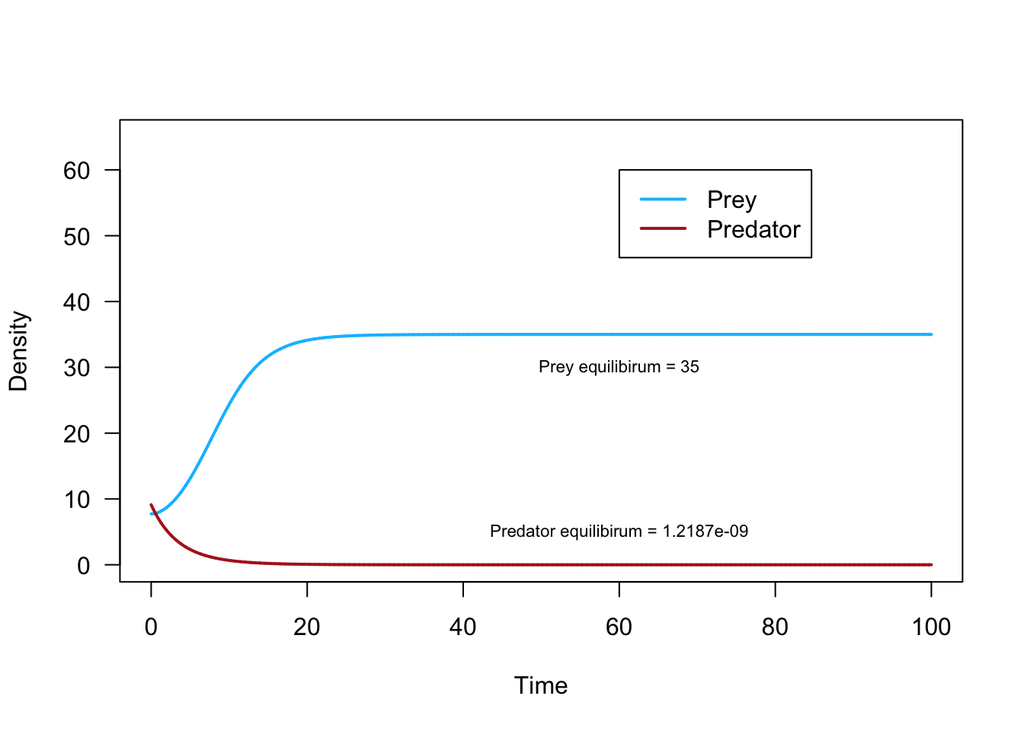

```r
Y = 200
h_x = 0.65
h_p = 0.325

#re-run for() loops but with new values for Y

# creating holding vectors and storing initial conditions - using initial time step, not extended
X.simu6 <- NaN*tset
X.simu6[1] <- X0_dis
P.simu6 <- NaN*tset
P.simu6[1] <- P0_dis

# using tset
for(i in 2:length(tset)){ #start at time step 2 from the second time step we set

  # if else statements
  ## if current time step is before (less than) t_stophunt hunting pressure stays as h_p
  ## else hunting pressure is set to 0 (no hunting after t_stophunt)
    if(tset[i] < t_stophunt){ h_p_now <- h_p } else { h_p_now <- 0 }

  ## if current time step is before (less than) t_stophunt hunting pressure stays as h_x
  ## else hunting pressure is set to 0 (no hunting after t_stophunt)
    if(tset[i] < t_stophunt){ h_x_now <- h_x } else { h_x_now <- 0 }

  # calculating change in time
    dt <- tset[i]-tset[i-1]

    # storing temporary variables
    X <- X.simu6[i-1] #prey at previous step
    P <- P.simu6[i-1] #preds at previous step

    # calculating change in population size
    dX <- (r_x*X*(1-X/K_x) - a_x*P*X - h_x_now*X ) * dt #hunting equation for prey (with new Y value)
    dP <- (P*(c*(a_x*X+a_y*Y)-d_p)*(1-P/K_p) - h_p_now*P ) * dt #hunting equation for preds (with new Y value)

    # calculating total population size and storing in holding vector
    X.simu6[i] <- X.simu6[i-1] + dX
    P.simu6[i] <- P.simu6[i-1] + dP
}

#and now plot

# plot prey (X.simu6) against time (tset2)
plot(x = tset, y = X.simu6,
     type = 'l', las = 1, lwd = 2, col = Xcol,
     xlab = 'Time', ylab = 'Density',
     ylim = c(0, 65))

# plot predator (P.simu6) against time (tset2)
lines(x = tset, y = P.simu6,
      lwd = 2, col = Pcol)

# add a legend
legend(x = 170, y = 65,
       lwd = 2,
       legend = c('Prey', 'Predator'),
       col = c(Xcol, Pcol))

# add vertical lines to indicate where hunting stopped
abline(v = t_stophunt, lty = 2, col = Pcol)
abline(v = t_stophunt, lty = 3, col = Xcol)

# add a legend
legend(x = 60, y = 60,
       legend = c('Prey','Predator'),
       lwd = 2,
       col = c(Xcol, Pcol))

#add numerical values for prey/preds equlibrium
text(x = 60, y = 30, 'Prey equilibirum = 35', cex = .7)
text(x = 60, y = 5, 'Predator equilibirum = 1.2187e-09', cex = .7)
```

```r
#print values for equlibrium of prey:
P.simu6[20000] #print value at last time step of predator
```

```
## [1] 1.2187e-09
```

```r
X.simu6[20000] #print value at last time step of predator
```

```
## [1] 35
```

##?how do we find tehse w math?

/1 equilibrium value for prey  
/1 equilibrium value for predator  
/2 code and graph that show work by simulation  
= /4 points total

## 4B

2. Simulate the three recovery scenarios (synchronous, predator-first, and prey-first). Create three timeseries graphs showing your results. Be sure to label your axes, include a legend, and indicate the time at which harvest stopped. HINT: You may need to run your timeseries for longer! Try `tset3 <- seq(100,500,length.out=22000)`

###SYNCHRONOUS

```r
tset3 <- seq(100,500,length.out=22000)

#have to reset Y
Y = 500

##SYNCHRONOUS:

# creating holding vectors and storing initial conditions
X.simu3 <- NaN*tset2
X.simu3[1] <- X0_dis
P.simu3 <- NaN*tset2
P.simu3[1] <- P0_dis

# using tset2: time from 100 to 210
for(i in 2:length(tset2)){ #start at time step 2 from the second time step we set

  # if else statements
  ## if current time step is before (less than) t_stophunt hunting pressure stays as h_p
  ## else hunting pressure is set to 0 (no hunting after t_stophunt)
    if(tset2[i] < t_stophunt){ h_p_now <- h_p } else { h_p_now <- 0 }

  ## if current time step is before (less than) t_stophunt hunting pressure stays as h_x
  ## else hunting pressure is set to 0 (no hunting after t_stophunt)
    if(tset2[i] < t_stophunt){ h_x_now <- h_x } else { h_x_now <- 0 }

  # calculating change in time
    dt <- tset2[i]-tset2[i-1]

    # storing temporary variables
    X <- X.simu3[i-1] #prey at previous step
    P <- P.simu3[i-1] #preds at previous step

    # calculating change in population size
    dX <- (r_x*X*(1-X/K_x) - a_x*P*X - h_x_now*X ) * dt #hunting equation for prey
    dP <- (P*(c*(a_x*X+a_y*Y)-d_p)*(1-P/K_p) - h_p_now*P ) * dt #hunting equation for preds

    # calculating total population size and storing in holding vector
    X.simu3[i] <- X.simu3[i-1] + dX
    P.simu3[i] <- P.simu3[i-1] + dP
}
```

plot

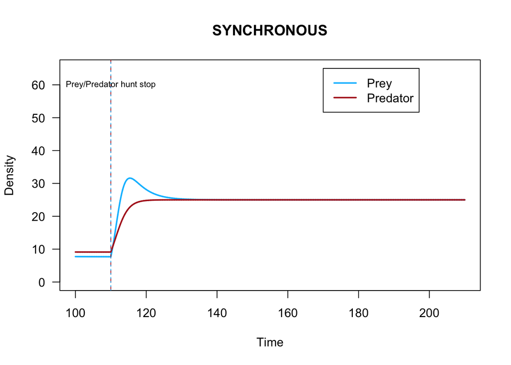

```r
# Scenario 3: Synchronous

# plot prey (X.simu3) against time (tset2)
plot(x = tset2, y = X.simu3,
     type = 'l', las = 1, lwd = 2, col = Xcol,
     xlab = 'Time', ylab = 'Density', main = "SYNCHRONOUS",
     ylim = c(0, 65))

# plot predator (P.simu3) against time (tset2)
lines(x = tset2, y = P.simu3,
      lwd = 2, col = Pcol)

# add a legend
legend(x = 170, y = 65,
       lwd = 2,
       legend = c('Prey', 'Predator'),
       col = c(Xcol, Pcol))

# add vertical lines to indicate where hunting stopped
abline(v = t_stophunt, lty = 2, col = Pcol)
abline(v = t_stophunt, lty = 3, col = Xcol)

# add label  to indicate when prey and pred hunting occurred
text(x = 110, y = 60, 'Prey/Predator hunt stop', cex = .7)
```

###PREDATOR FIRST

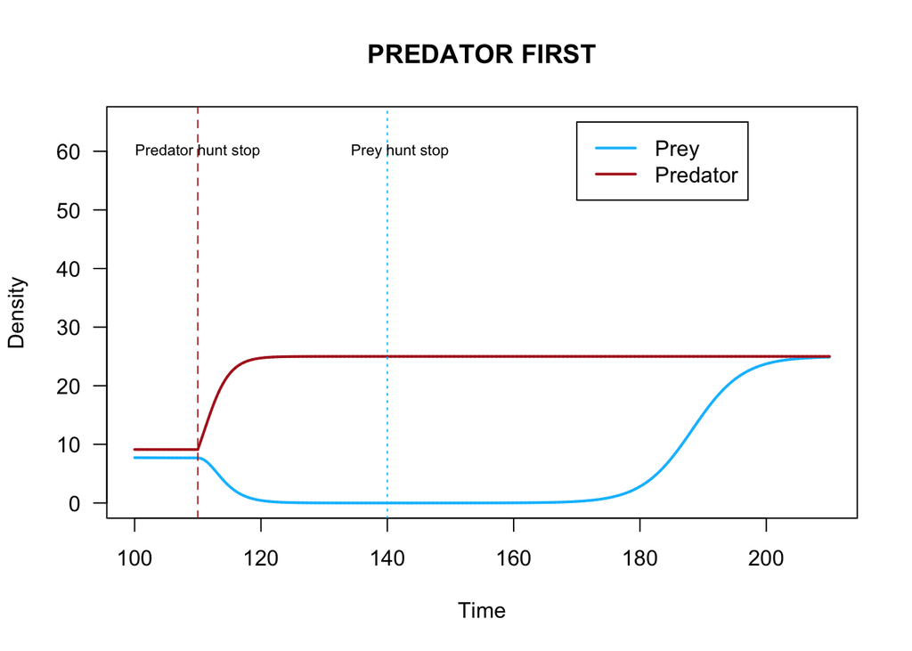

```r
#PREDATOR FIRST
t_stopX <- 140 #prey stop comes after
t_stopP <- 110 #predator stop comes first

#creating holding vectors and storing initial conditions
X.simu4 <- NaN*tset2
X.simu4[1] <- X0_dis
P.simu4 <- NaN*tset2
P.simu4[1] <- P0_dis

for(i in 2:length(tset2)){

  # if time is before t_stopP, h_p_now = h_p
  # else, h_p_now = 0
    if(tset2[i] < t_stopP){ h_p_now <- h_p } else { h_p_now <- 0 }

  # if time is before t_stopX, h_x_now = h_x
  # else, h_x_now = 0
    if(tset2[i] < t_stopX){ h_x_now <- h_x } else { h_x_now <- 0 }

  # calculating change in time
    dt <- tset2[i]-tset2[i-1]

    # storing temporary variables
    X <- X.simu4[i-1]
    P <- P.simu4[i-1]

    # calculating change in population size
    dX <- ( r_x*X*(1-X/K_x) - a_x*P*X - h_x_now*X ) * dt #prey
    dP <- ( P*(c*(a_x*X+a_y*Y)-d_p)*(1-P/K_p) - h_p_now*P ) * dt #pred

    # calculating total population size and storing in holding vector
    X.simu4[i] <- X.simu4[i-1] + dX
    P.simu4[i] <- P.simu4[i-1] + dP
}

#plot
# plot prey (X.simu4) against time (tset2)
plot(x = tset2, y = X.simu4,
     type = 'l', las = 1, lwd = 2, col = Xcol,
     xlab = 'Time', ylab = 'Density', main = "PREDATOR FIRST",
     ylim = c(0, 65))

# plot predator (P.simu4) against time (tset2)
lines(x = tset2, y = P.simu4,
      lwd = 2, col = Pcol)

# add a legend
legend(x = 170, y = 65,
       lwd = 2,
       legend = c('Prey', 'Predator'),
       col = c(Xcol, Pcol))

# add vertical lines to indicate where hunting stopped
abline(v = t_stopP, lty = 2, col = Pcol)
abline(v = t_stopX, lty = 3, col = Xcol)

# add label  to indicate when prey hunting occurred
text(x = 142, y = 60, 'Prey hunt stop', cex = .7)

# add label to indicate where predator hunting occurred
text(x = 110, y = 60, 'Predator hunt stop', cex = .7)
```

###PREY FIRST

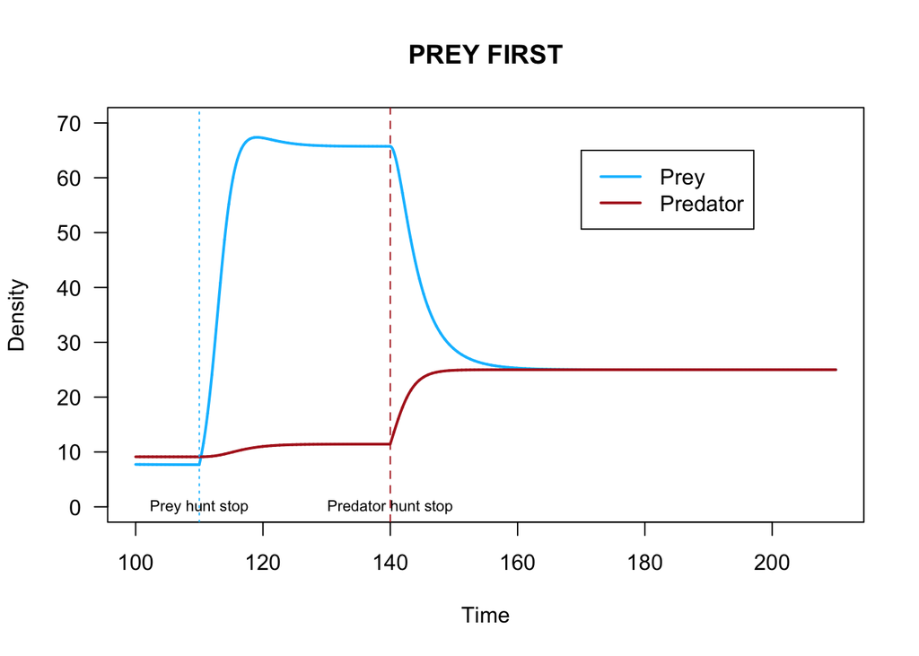

```r
#PREY FIRST
t_stopX <- 110 #prey stop comes first
t_stopP <- 140 #predator stop comes after

#creating holding vectors and storing initial conditions
X.simu4 <- NaN*tset2
X.simu4[1] <- X0_dis
P.simu4 <- NaN*tset2
P.simu4[1] <- P0_dis

for(i in 2:length(tset2)){

  # if time is before t_stopP, h_p_now = h_p
  # else, h_p_now = 0
    if(tset2[i] < t_stopP){ h_p_now <- h_p } else { h_p_now <- 0 }

  # if time is before t_stopX, h_x_now = h_x
  # else, h_x_now = 0
    if(tset2[i] < t_stopX){ h_x_now <- h_x } else { h_x_now <- 0 }

  # calculating change in time
    dt <- tset2[i]-tset2[i-1]

    # storing temporary variables
    X <- X.simu4[i-1]
    P <- P.simu4[i-1]

    # calculating change in population size
    dX <- ( r_x*X*(1-X/K_x) - a_x*P*X - h_x_now*X ) * dt #prey
    dP <- ( P*(c*(a_x*X+a_y*Y)-d_p)*(1-P/K_p) - h_p_now*P ) * dt #pred

    # calculating total population size and storing in holding vector
    X.simu4[i] <- X.simu4[i-1] + dX
    P.simu4[i] <- P.simu4[i-1] + dP
}

#plot
# plot prey (X.simu4) against time (tset2)
plot(x = tset2, y = X.simu4,
     type = 'l', las = 1, lwd = 2, col = Xcol,
     xlab = 'Time', ylab = 'Density', main = "PREY FIRST",
     ylim = c(0, 70))

# plot predator (P.simu4) against time (tset2)
lines(x = tset2, y = P.simu4,
      lwd = 2, col = Pcol)

# add a legend
legend(x = 170, y = 65,
       lwd = 2,
       legend = c('Prey', 'Predator'),
       col = c(Xcol, Pcol))

# add vertical lines to indicate where hunting stopped
abline(v = t_stopP, lty = 2, col = Pcol)
abline(v = t_stopX, lty = 3, col = Xcol)

# add label  to indicate when prey hunting occurred
text(x = 110, y = 0, 'Prey hunt stop', cex = .7)

# add label to indicate where predator hunting occurred
text(x = 140, y = 0, 'Predator hunt stop', cex = .7)
```

/3 axes for three plots  
/6 predator and prey lines for three plots  
/6 graphical indication of when hunting stops  
/3 legends for three plots  
= /18 points total

## 4C

3. Compare your findings to one another. For which scenario was overall recovery to an unexploited state fastest?

**Synchronous was the fastest recovery, stopping predator hunting first and prey after led to a delayed response in the prey species. Prey first stopping of hunting led to an immediate jump in prey species with predators being hunted still and after hutning stopped of both, this scenario recovered second fastest**

**The overall recovers to an unexploited state was fastest in: Synchronous scenario**

= /2 points total

## 4D

4. Compare your findings to those of Samhouri et al. (2017). What do your results suggest about the importance of a secondary prey type to predator-first recovery?

**They agree that stopping hunting of prey and predator in a synchronous timeline lead to fastest recovery. Secondary prey types are important in leading to predator first recovery because the other two prey types are then impacted by the predator population and the high density of one prey type leads to low densities of the other as one gets preyed upon more.**

= /2 points total

= /48 points total